### Explore Reasons Behind Dramatic Difference between AQI Reported by U.S. and China

#### Group1: Li Luo, Zhuangye Chen

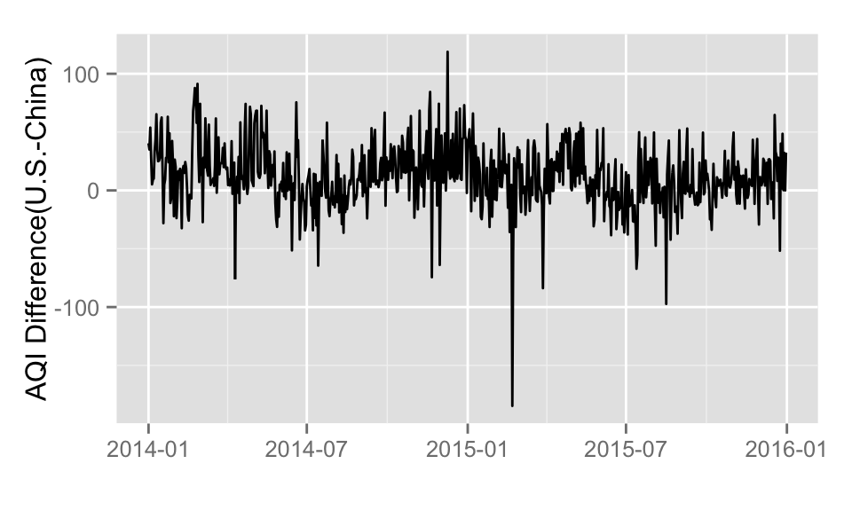

```r
suppressPackageStartupMessages(library(dplyr))
library(ggplot2)
library(readxl)
aqidiff <- read_excel("aqi_raw.xlsx", sheet = 1)
# Inpute missing values from other data sources
aqidiff[is.na(aqidiff$China_AQI), "China_AQI"] <- c(330, 215, 209, 186, 181, 71, 33)

# Adjust PM2.5
x <- c(0, 14.3, 28.6, 42.9, 56.3, 68.8, 81.3, 93.8, 106.3, 118.8, 131.3, 143.8, 157.1, 171.4, 185.7, 200)
y <- c(0, 32, 62, 87, 108, 125, 141, 154, 159, 165, 171, 177, 182, 188, 194, 200)
adj_lm <- lm(y~I(x^3)+I(x^2)+x+0)
adj_china_aqi <- unlist(sapply(1:dim(aqidiff)[1], function(x) ifelse(aqidiff$Main_Pollutant[x] == "PM2.5" && !is.na(aqidiff$Main_Pollutant[x]) && aqidiff$China_AQI[x] < 200, predict(adj_lm, newdata = data.frame(x = aqidiff$China_AQI[x])), aqidiff$China_AQI[x])))

aqidiff <- aqidiff %>% mutate(China_aqi_adj = adj_china_aqi) %>% mutate(aqi_diff = US_AQI - China_aqi_adj) %>% select(Date, China_AQI, US_AQI, China_aqi_adj, aqi_diff)
#head(aqidiff)
#summary(aqidiff)
ggplot(aqidiff, aes(Date, aqi_diff)) + geom_line() + xlab("") + ylab("AQI Difference(U.S.-China)")
```

Chinese and U.S. governments use different methods to calculate Air Quality Index (AQI). While both indexes are based on the same formula (First calculate the sub-AQI for each pollutant and use the maximum one for the overall AQI, see https://en.wikipedia.org/wiki/Air_quality_index#Computing_the_AQI), they measure different types of particles and use different cutoff points in the calculation.

To adjust for the difference in the calculation, we used linear regression of U.S. AQI on China AQI according the chart of different AQI’s corresponding to the same PM2.5 concentration (http://gzaqi.sinaapp.com/static/html/compare.html). Since in this report, our main concern is PM2.5, at this point we only adjust for days when the main source of pollutant is PM2.5. In the future, we could use the similar method to adjust for other pollutants if needed.

In order to check if the differences in AQI is not zero, we need to check the `aqidiff` time series data is stationary and the mean is away from zero. Here, we first delete the overall mean of `aqidiff` 12.1317722 from the original data of `aqidiff` and then use ADF test to check if this series is stationary with mean zero. With NA in the data, we need to delete all the NA rows in order to do the ADF test.

```r
zeromean <- aqidiff$aqi_diff-mean(aqidiff$aqi_diff)
#ts.plot(zeromean)
library(tseries)
pvalue <- adf.test(zeromean)$p.value
pvalue
```

```
## [1] 0.01
```

From the test result, the p-value is 0.01,which means the data is stationary. Thus, we can conclude that the differences of AQI reported by China and US really exist.

Next, we will try to find out when the differences are relatively large and what reasons lead to this result. Some useful references may be: Comparative Analysis and Inspiration of Air Quality Index Between China and America by GAO Qing-xian et al and ‘Effortless Perfection:’ Do Chinese cities manipulate air pollution data? by Ghanem and Zhang.

##### 2/10

```r
# top 10 days by AQI diff
aqidiff %>% arrange(desc(aqi_diff)) %>% head(10)
```

```
## Source: local data frame [10 x 5]
##
##          Date China_AQI   US_AQI China_aqi_adj  aqi_diff
##        (time)     (dbl)    (dbl)         (dbl)     (dbl)
## 1  2014-12-09       276 394.8462           276 118.84615
## 2  2014-02-26       330 421.3333           330  91.33333
## 3  2014-02-23       255 342.7826           255  87.78261
## 4  2014-02-24       313 398.9583           313  85.95833
## 5  2014-11-19       282 366.4167           282  84.41667
## 6  2014-02-22       311 387.4167           311  76.41667
## 7  2014-06-19       116 191.5000           116  75.50000
## 8  2014-11-29       276 350.2917           276  74.29167
## 9  2014-03-01        68 142.2083            68  74.20833
## 10 2014-04-22        85 159.1667            85  74.16667
```

Notice all 10 days are in 2014. If we list top 10 AQI difference in 2015:

```r
aqidiff %>% filter(strftime(Date, format = "%Y") == 2015) %>% arrange(desc(aqi_diff)) %>% head(10)
```

```
## Source: local data frame [10 x 5]
##
##          Date China_AQI   US_AQI China_aqi_adj aqi_diff
##        (time)     (dbl)    (dbl)         (dbl)    (dbl)
## 1  2015-01-07        85 150.9565            85 65.95652
## 2  2015-12-18        80 144.6667            80 64.66667
## 3  2015-05-10        59 117.0833            59 58.08333
## 4  2015-04-02        50 106.7917            50 56.79167
## 5  2015-04-27       115 168.3333           115 53.33333
## 6  2015-05-13       102 155.2917           102 53.29167
## 7  2015-06-05        71 124.2917            71 53.29167
## 8  2015-09-09        50 103.0417            50 53.04167
## 9  2015-02-06       100 152.8750           100 52.87500
## 10 2015-04-23        80 132.6667            80 52.66667
```